# A3: Incarceration

### Introduction

Though this analysis I will be examining the rate of incarcerations based on location (rural/urban) in the state of Washington. Additionally, I will examine how race impacts the rate of incarceration in Washington. By limiting the scope of analysis to a singular state, there is more specific insight available into how race can impact incarceration rates. Specifically, I will be examining the rate of Native American incarcerations against the rate of white incarcerations. Due to the relevance of this issue, as the Pacific Northwest and Washington as a whole is a place where many Native Americans reside, the comparison can shed light on discriminatory behavior within the U.S. law enforcement systems. To allow for a more focused scope, I will also only be examining on the jail population rates. I will be doing this for two reasons: there is little information provided in the data frame about prison rates for Native Americans, and the jail rates can provide direct insight into the rate in which Native Americans are arrested.

### Summary Information

The variables I collected give insight to the rates in which white people are arrested and put in jail compared to the rate Native Americans are arrested. For simplicity, as stated above, I am focusing on specifically Washington state. I used the total jail population per county and state for my analysis as it provides jail numbers rather than rates that were given in the Washington specific table. I created a new data frame containing only WA state data. I found the total Native American jail population over time (1963- present) to be 15551.37 and White jail population to be 222168.9. In order to gauge the percentage of Native Americans and White people incarcerated I then determined the total population of each group. According to the data, in Washington state there are 1,961,627 Native Americans with an incarceration rate of about %0.7927. A total population of 94,711,492 White people reside in Washington with an incarceration rate of about %0.2346. the rate of incarceration for Native Americans in the U.S. is significantly higher than that of white people. As discussed prior, I also want to examine the way urbanicity may play into the rate of incarceration of people and Native Americans in specific. Small/mid areas contain the most incarcerations at 153668.39, compared to urban areas at 98932.50. Native Americans make up %13.974 of small/mid area population, and white people make up %55.9 of small/mid area population. This information displays the disproportionate rate in which Native Americans are incarcerated (specifically jail population) compared to the rate in which white people are incarcerated.

### The Dataset

This data was collected by Vera in order to provide insight into the rates of incarceration by state and county, as well as details into how different racial groups are disproportionately incarcerated. Through data collections by the Bureau of Justice Statistics (BJS), Vera collected its data from the Census of Jails (COJ) and the Annual Survey of Jails (ASJ). Both data collections provide statistics about jail populations. There is a companion project which collects data containing prison populations from the National Corrections Reporting Program. Both these data sets are combined to show detailed incarceration statistics at the county level. The population estimates provided in the data set come from the Census Bureau and the Center for Disease Control Prevention, and the geographical data is derived from the U.S. Department of Agriculture. There are 153,811 rows and 28 columns in the data set about jail population by county and state. The ethical problems that arise when examining this data is the diversity that goes beyond just race. The data set does not take into account economic and educational background, it only displays the incarceration by race. This could be misleading to someone looking only at the data and disregarding socioeconomic context. The data is also limited for the same reason. Additionally, the data is limited in the amount of information provided for each group. For example, many values are blank when looking at data about Native American incarceration. This may be due to the way it was collected: compiling data from different sources each of which collected data in different ways and during different time periods.

### Trends Over Time Chart

The chart below depicts how incarceration rates have changed since 1990 for two races: white people and Native Americans. Both Washington state and National trends are depicted in the chart. This is valuable in visualizing the difference in incarceration rates for the two groups, and how the rates in Washington State differ from the United States as a whole.

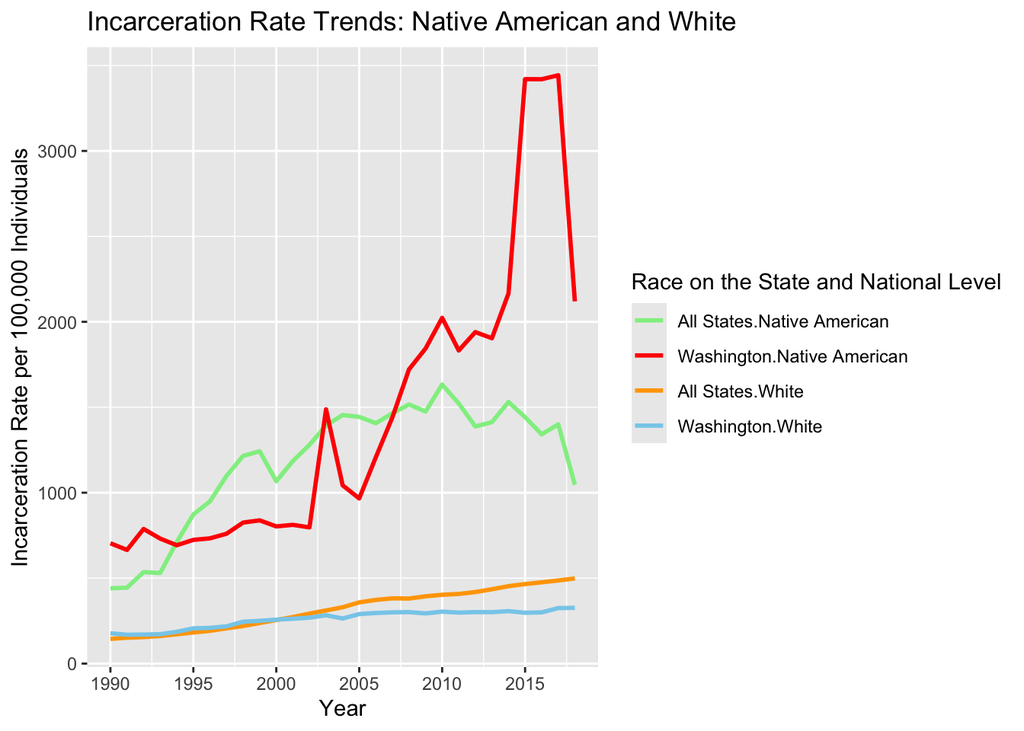

### Variable Comparison Chart

Below is a chart containing the rate in which white and Native American people are incarcerated in each category of urbanicity. Additionally, the rate that Native American people is shown by the green bar lines. This is beneficial in understanding how environment can impact incarceration rates for minority groups such as Native Americans.

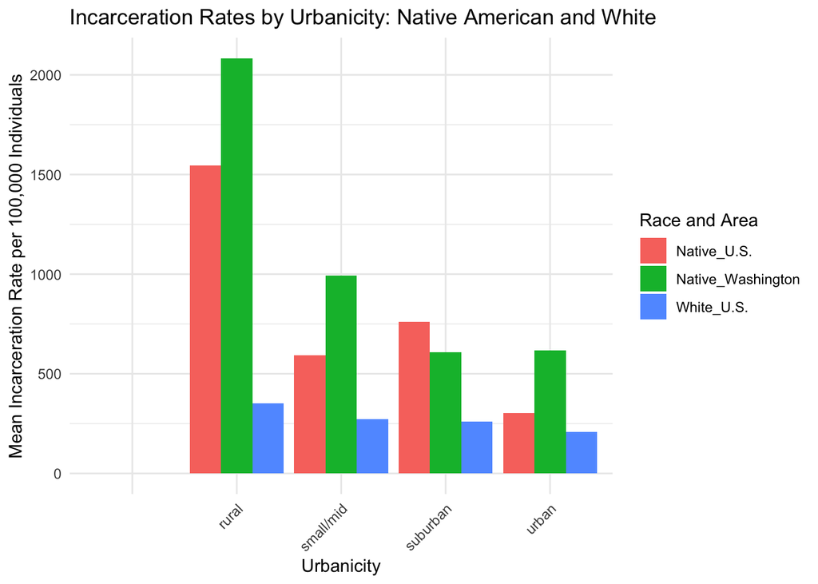

### Map

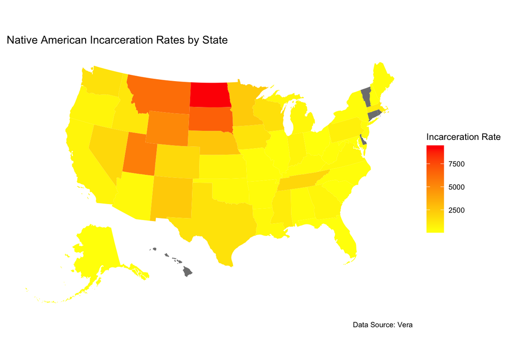